# 4.21: Limits to small effect size estimates

Alex Kindel

November 22, 2016

### Works referenced

Lewis, Randall A., and Justin M. Rao. 2015. “The Unfavorable Economics of Measuring the Returns to Advertising.” The Quarterly Journal of Economics 130 (4): 1941–73. doi:10.1093/qje/qjv023.

### Background

Imagine that you are working as a data scientist at a tech company. Someone from the marketing department asks for your help in evaluating an experiment that they are planning in order to measure the Return on Investment (ROI) for a new online ad campaign. (ROI is defined to be the net profit from the campaign divided by the cost of the campaign. For example, a campaign that had no effect on sales would have an ROI of -100%; a campaign where profits generated were equal to costs would have an ROI of 0; and a campaign where profits generated were double the cost would have an ROI of 200%).

Before launching their experiment, the marketing department provides you with the following information based on their earlier research (in fact, these values are typical of the real online ad campaigns reported in Lewis and Rao (2015)):

- the mean sales per customer is $7 with a standard deviation of $75.
- the campaign is expected to increase sales by $0.35 per customer which corresponds to an increase in profit of $0.175 per customer.
- the planned size of the experiment is 200,000 people, half in the treatment group and half in the control group.
- the cost of the campaign is $0.14 per participant.

```r
# Customer and campaign parameters
sales.m <- 7  # Mean sales
sales.sd <- 75  # Sales SD
ssize <- 200000  # Customer base
p.treat <- 0.5  # Even split
mg.cost <- 0.14  # Campaign cost per customer
mg.sales <- 0.35  # Marginal campaign effect
tot.cost <- mg.cost * ssize  # Campaign cost total
```

### Simulation approach

We begin with the example values above. The proposed experiment parameters yield a Cohen’s $d$ of 0.0046667. This yields a power of around 0.181—much lower than the standard 0.8 To see why this is problematic, we can start by simulating the sampling distribution of the difference in means over many simulated experiments. We randomly assign ($P(treat) = 0.5$) 200k customers to treatment or control, and simulate “observed” sales data with an added effect for treatment $\delta y$:

```r
# Define assignments for N customers
sales <- function(ssize, p.treat) {
  treat <- rlnorm(ssize * p.treat, mean=sales.m + mg.sales, sd=sales.sd)
  ctrl <- rlnorm(ssize * p.treat, mean=sales.m, sd=sales.sd)
  return(list(treat=treat, ctrl=ctrl))
}

# Generate sales and test difference in means
sales.diffm <- function(ssize, p.treat) {
  custs <- lapply(sales(ssize, p.treat), log)
  tt <- t.test(custs[["ctrl"]], custs[["treat"]])
  return(c(diffm=tt[["estimate"]][2] - tt[["estimate"]][1],
           pval=tt[["p.value"]]))
}
```

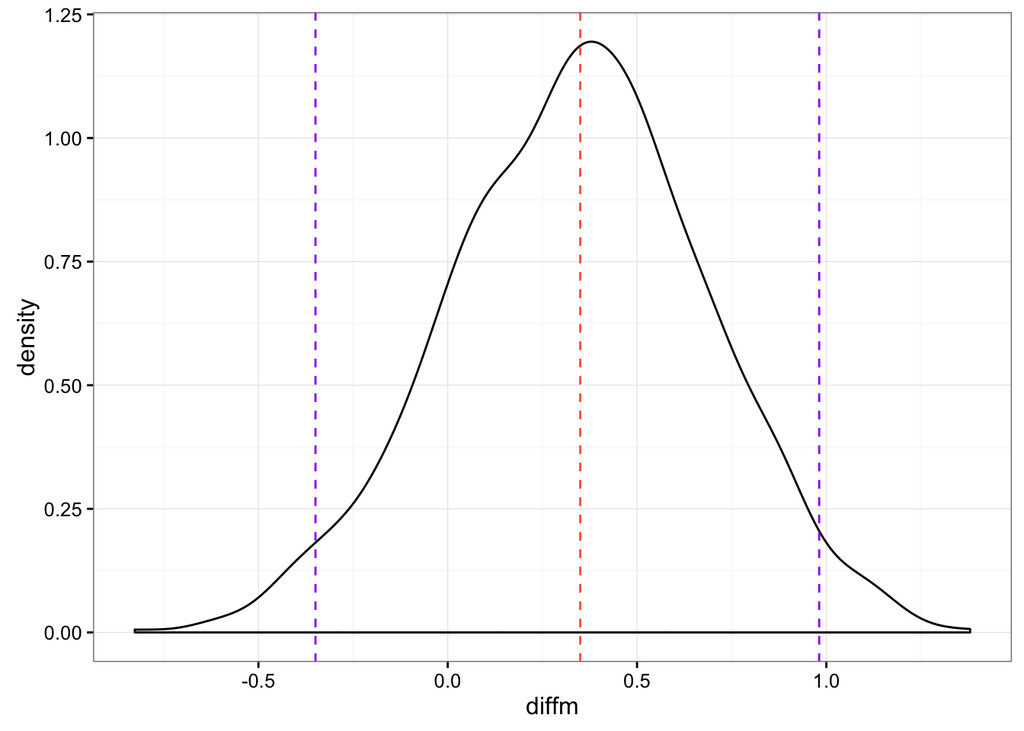

```r
# Generate empirical sampling distribution of difference in means
k <- 1000
dm1.sdist <- replicate(k, sales.diffm(ssize, p.treat))
dm1.sdist <- data.frame(t(as.matrix(dm1.sdist)))
dm1.sdist %<>% dplyr::rename(diffm=diffm.mean.of.y) %>% arrange(diffm)

# Determine empirical 95% confidence interval
lt.e <- dm1.sdist[.025*k,'diffm']
rt.e <- dm1.sdist[.975*k,'diffm']

# Plot sampling distribution
dm1.sdist %>%
  ggplot(aes(x = diffm)) +
  geom_density() +
  geom_vline(xintercept=mg.sales, color="tomato", linetype="dashed") +
  geom_vline(xintercept=lt.e, linetype="dashed", color="purple") +
  geom_vline(xintercept=rt.e, linetype="dashed", color="purple")
```

The first thing we notice is that while our distribution collapses around the correct difference in means, the confidence interval on our estimate suggests that our sample size is not large enough to make a meaningful claim about the effectiveness of the experiment

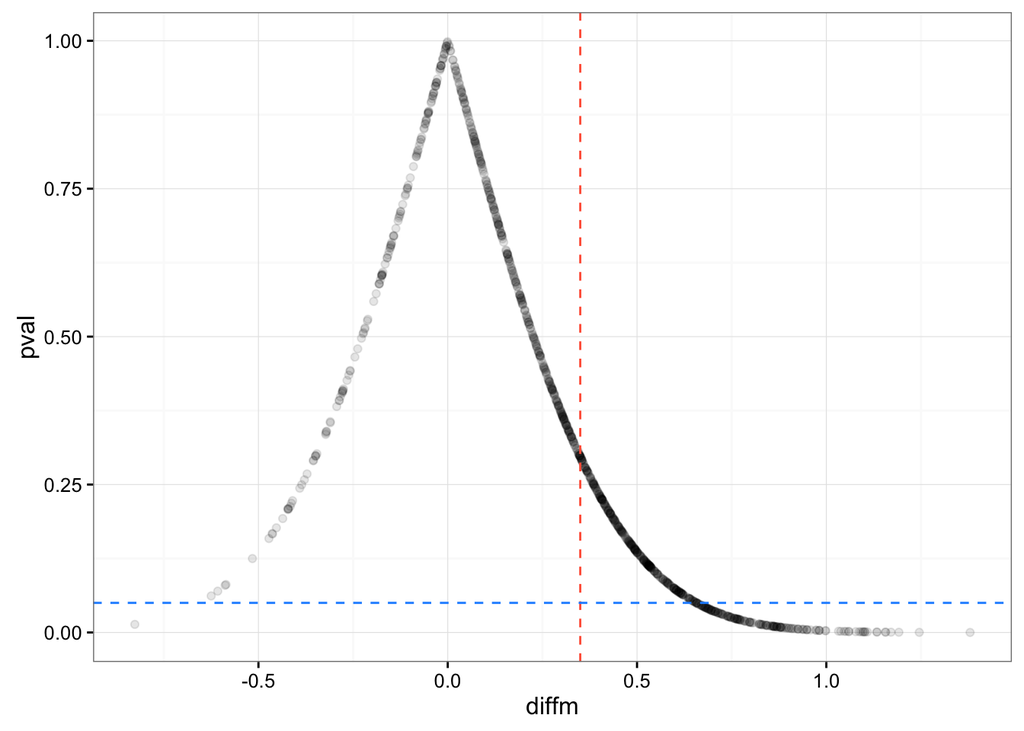

```r
# Plot estimated difference in means against p value of t-test
dm1.sdist %>%
  ggplot(aes(x=diffm, y=pval)) +
  geom_point(alpha=0.1) +
  geom_vline(xintercept=mg.sales, color="tomato", linetype="dashed") +
  geom_hline(yintercept=0.05, color="dodgerblue", linetype="dashed")
```

Perhaps more troublingly, if we *were* to find a significant effect, we would substantially overestimate the effect size. To achieve $p < .05$ we need to observe an effect size of around .66, which is almost twice the real effect size.

This does not seem to be a good use of our resources: this experiment would cost $28000 to run, and it’s inconclusive at best—and misleading at worst! What would it take to fix the experiment? Let’s try adjusting the sample size of our experiment by a factor of 10, to reach 2 million customers:

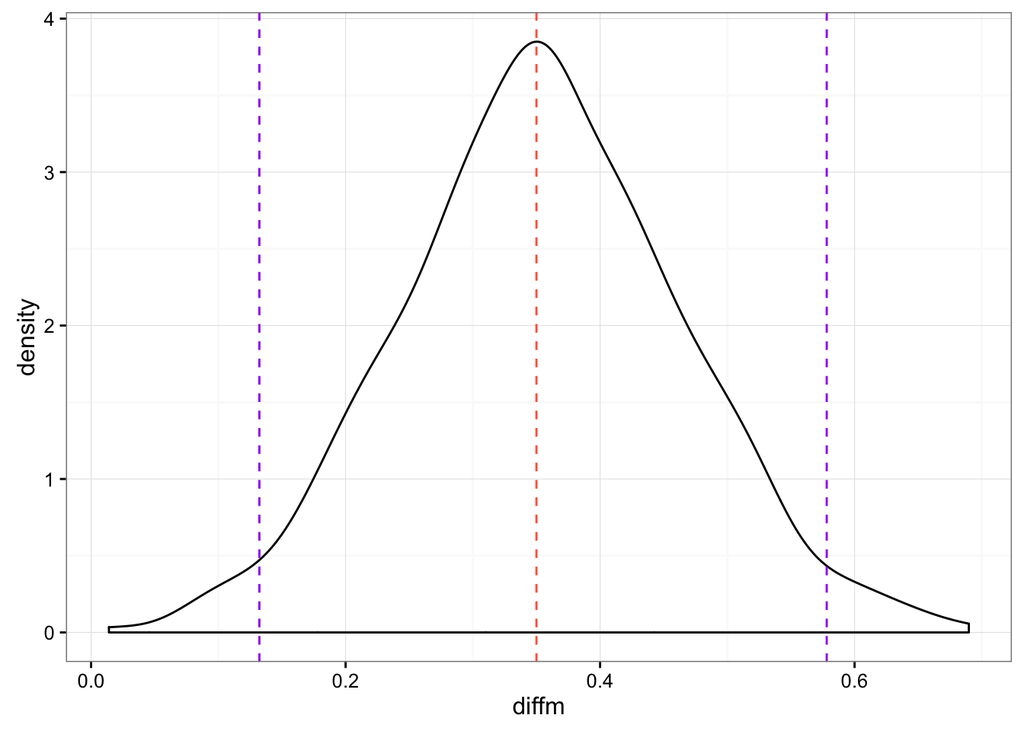

```r
# Generate empirical sampling distribution of difference in means
k <- 500
ssize <- 2000000
dm1.sdist <- replicate(k, sales.diffm(ssize, p.treat))
dm1.sdist <- data.frame(t(as.matrix(dm1.sdist)))
dm1.sdist %<>% dplyr::rename(diffm=diffm.mean.of.y) %>% arrange(diffm)

# Determine empirical 95% confidence interval
lt.e <- dm1.sdist[.025*k,'diffm']
rt.e <- dm1.sdist[.975*k,'diffm']

# Plot sampling distribution
dm1.sdist %>%
  ggplot(aes(x = diffm)) +
  geom_density() +
  geom_vline(xintercept=mg.sales, color="tomato", linetype="dashed") +
  geom_vline(xintercept=lt.e, linetype="dashed", color="purple") +
  geom_vline(xintercept=rt.e, linetype="dashed", color="purple")
```

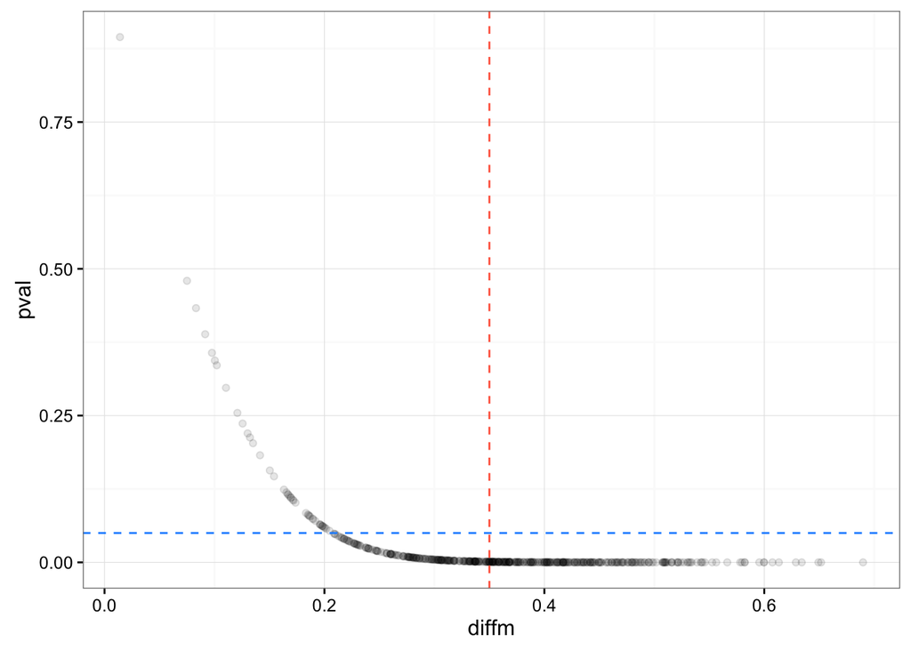

```r
# Plot estimated difference in means against p value of t-test
dm1.sdist %>%
  ggplot(aes(x=diffm, y=pval)) +
  geom_point(alpha=0.1) +
  geom_vline(xintercept=mg.sales, color="tomato", linetype="dashed") +
  geom_hline(yintercept=0.05, color="dodgerblue", linetype="dashed")
```

### Analytical approach

We are interested in the impact-to-standard-deviation ratio ($\frac{\delta y}{\sigma}$) given $\delta y$ = 0.35 and $\hat{\sigma}$ = 75.

Lewis and Rao provide two useful formulas for calculating $R^{2}$ and $t_{\delta y}$:

$$R^{2} = \frac{1}{4}(\frac{\delta y}{\hat{\sigma}})^{2} \\
t_{\delta y} = \sqrt{\frac{N}{2}}(\frac{\delta y}{\hat{\sigma}})$$

```r
rsq <- function(dy, s) { 0.25 * (dy / s) ^ 2 }
t.dy <- function(n, dy, s) { sqrt(n / 2) * (dy / s) }
```

To put it in different terms, the low $R^{2}$ (or more pertinently, the low impact-to-standard-deviation ratio) means that assignment to treatment explains very little of the variance in sales. To have any hope of detecting a significant (say, $p < .05$) effect in the difference in means between our experimental groups, we are going to need to either drive up our sample size or find some way of adjusting either the effectiveness of our advertising or the variance in our marginal sales.

Another way of rephrasing this is: what sample size would enable us to drive up our test statistic $t_{\delta y}$ to a given critical value? For a 95% confidence interval in large samples, this critical value is approximately equal to 1.96. We compute:

$$\begin{aligned}
t_{\delta y}&= 1.96. \\
\sqrt{\frac{N}{2}}(\frac{\delta y}{\hat{\sigma}}) &= 1.96 \\
\sqrt{\frac{N}{2}} &= \frac{1.96 \hat{\sigma}}{\delta y} \\
\frac{N}{2} &= (\frac{1.96 \hat{\sigma}}{\delta y})^2 \\
N &= 2(\frac{1.96 \hat{\sigma}}{\delta y})^2 \\
N & \approx 352800.
\end{aligned}$$

Note that since we’re using a two-sided t-statistic, we need to multiply $N$ by 2 to pin down the sign of the difference in means.

So our original experiment was underpowered by a little more than 500k customers– which is quite a gap! Let’s see what we might be able to do with a fixed customer sample size by adjusting our impact-to-standard-deviation ratio. First, we can determine what marginal effect size (that is, marginal sales increase on treatment, $\delta y$) we would need for our customer sample size to work:

$$\begin{aligned}
t_{\delta y}&= 1.96. \\
\sqrt{\frac{N}{2}}(\frac{\delta y}{\hat{\sigma}}) &= 1.96 \\
\frac{\delta y}{\hat{\sigma}} &= \frac{1.96}{\sqrt{N / 2}} \\
\delta y &= \frac{1.96\hat{\sigma}}{\sqrt{N / 2}} \\
\delta y & \approx 0.465.
\end{aligned}$$

We can do the same for our variance in sales:

$$\begin{aligned}
t_{\delta y}&= 1.96. \\
\sqrt{\frac{N}{2}}(\frac{\delta y}{\hat{\sigma}}) &= 1.96 \\
\sqrt{\frac{N}{2}}(\delta y) &= 1.96\hat{\sigma} \\
\hat{\sigma} &= \sqrt{\frac{N}{2}}(\frac{\delta y}{1.96}) \\
\hat{\sigma} & \approx 56.47.
\end{aligned}$$

In simpler terms, for our customer sample size $N = 200000$ to work, we would need to increase the average marginal sales for our advertising campaign by approximately $0.11, or we would need to decrease the variance in our per-customer sales by approximately $19.